# Homework 1, Econ B2000

Christopher Tinevra, Group Members: Isabela Vieira, Akimawe Kadiri, Nicole Kerrison, Mostafa Ragheb

9/14/2020

### Question 3: “Simulating a Dice Roll”

Theoretical probability of roll - the expectation is to roll a 6 on a dice of 6 sides for at least once 1/36= (.02778)

In order to create a fair dice simulation in R. We first begin by creating a variable called dice rolls and set the size to 2 representing the utilization of 2 dice and any time we roll we want replacements of numbers.

```r
die.rolls <- function (){
  dice <- sample(x=1:6, size = 2, replace = TRUE)}
```

Then we want to create a simulation that runs this at least 20 times

```r
simtrial <- replicate(20,die.rolls())
```

Then create a table to of the simulation once its complete.

```r
table(simtrial)
```

```
## simtrial
##  1  2  3  4  5  6
##  8  3  3  8 14  4
```

#Then generate the frequency of the outcome and plot the data

Frequency - this is the % of times we virtually rolled the numbers below

```r
table(simtrial)/length(simtrial)
```

```
## simtrial
##     1     2     3     4     5     6
## 0.200 0.075 0.075 0.200 0.350 0.100
```

Plot - This plots the number of times in the simulation roll that we record a number

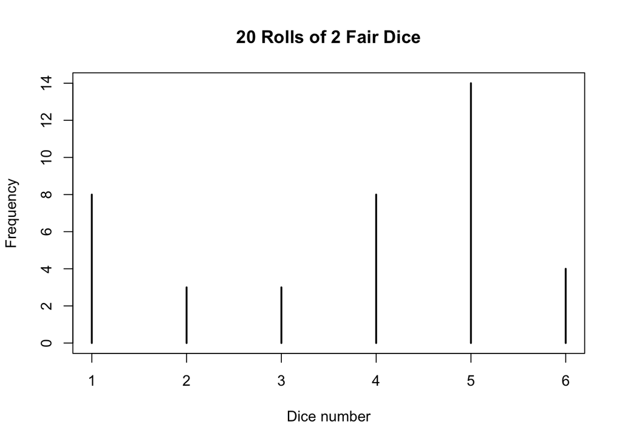

```r
plot(table(simtrial), xlab = 'Dice number', ylab = 'Frequency', main = '20 Rolls of 2 Fair Dice')
```

### Question 4: “Replication of Lecture 1 Rstudio notes”

```r
load("acs2017_ny_data.RData")
acs2017_ny[1:10,1:7]
```

```
##    AGE female educ_nohs educ_hs educ_somecoll educ_college educ_advdeg
## 1   72      1         0       0             0            0           1
## 2   72      0         0       0             0            0           1
## 3   31      0         0       0             0            1           0
## 4   28      1         0       0             0            1           0
## 5   54      0         0       0             0            0           1
## 6   45      1         0       1             0            0           0
## 7   84      1         0       0             1            0           0
## 8   71      0         0       0             0            1           0
## 9   68      1         0       0             1            0           0
## 10  37      1         1       0             0            0           0
```

```r
attach(acs2017_ny)
```

```r
summary(acs2017_ny)
```

```
##       AGE            female         educ_nohs        educ_hs
##  Min.   : 0.00   Min.   :0.0000   Min.   :0.000   Min.   :0.0000
##  1st Qu.:22.00   1st Qu.:0.0000   1st Qu.:0.000   1st Qu.:0.0000
##  Median :42.00   Median :1.0000   Median :0.000   Median :0.0000
##  Mean   :41.57   Mean   :0.5156   Mean   :0.271   Mean   :0.2804
##  3rd Qu.:60.00   3rd Qu.:1.0000   3rd Qu.:1.000   3rd Qu.:1.0000
##  Max.   :95.00   Max.   :1.0000   Max.   :1.000   Max.   :1.0000
##
##  educ_somecoll    educ_college     educ_advdeg                  SCHOOL
##  Min.   :0.000   Min.   :0.0000   Min.   :0.000   N/A              :  5569
##  1st Qu.:0.000   1st Qu.:0.0000   1st Qu.:0.000   No, not in school:144968
##  Median :0.000   Median :0.0000   Median :0.000   Yes, in school   : 46048
##  Mean   :0.173   Mean   :0.1567   Mean   :0.119   Missing          :     0
##  3rd Qu.:0.000   3rd Qu.:0.0000   3rd Qu.:0.000
##  Max.   :1.000   Max.   :1.0000   Max.   :1.000
##
##                         EDUC
##  Grade 12                 :55119
##  4 years of college       :30802
##  5+ years of college      :23385
##  1 year of college        :19947
##  Nursery school to grade 4:14240
##  2 years of college       :14065
##  (Other)                  :39027
##                                           EDUCD
##  Regular high school diploma                 :35689
##  Bachelor's degree                           :30802
##  1 or more years of college credit, no degree:19947
##  Master's degree                             :17010
##  Associate's degree, type not specified      :14065
##  Some college, but less than 1 year          : 9086
##  (Other)                                     :69986
##                                      DEGFIELD
##  N/A                                     :142398
##  Business                                :  9802
##  Education Administration and Teaching   :  6708
##  Social Sciences                         :  4836
##  Medical and Health Sciences and Services:  3919
##  Fine Arts                               :  3491
##  (Other)                                 : 25431
```

[output cut: 209 more lines]

```
##  Min.   :0.00000   Min.   :0.00000   Min.   :0.000     Min.   :0.0000
##  1st Qu.:0.00000   1st Qu.:0.00000   1st Qu.:0.000     1st Qu.:0.0000
##  Median :0.00000   Median :0.00000   Median :0.000     Median :0.0000
##  Mean   :0.01332   Mean   :0.05506   Mean   :0.122     Mean   :0.1965
##  3rd Qu.:0.00000   3rd Qu.:0.00000   3rd Qu.:0.000     3rd Qu.:0.0000
##  Max.   :1.00000   Max.   :1.00000   Max.   :1.000     Max.   :1.0000
##
##  below_200poverty   foodstamps
##  Min.   :0.0000   Min.   :0.0000
##  1st Qu.:0.0000   1st Qu.:0.0000
##  Median :0.0000   Median :0.0000
##  Mean   :0.2676   Mean   :0.1465
##  3rd Qu.:1.0000   3rd Qu.:0.0000
##  Max.   :1.0000   Max.   :1.0000
##
```

```r
print(NN_obs <- length(AGE))
```

```
## [1] 196585
```

Sample size for this database equates to 196,585

```r
summary(AGE[female == 1])
```

```
##    Min. 1st Qu.  Median    Mean 3rd Qu.    Max.
##    0.00   23.00   44.00   42.72   61.00   95.00
```

```r
summary(AGE[!female])
```

```
##    Min. 1st Qu.  Median    Mean 3rd Qu.    Max.
##    0.00   21.00   40.00   40.35   59.00   95.00
```

```r
mean(AGE[female == 1])
```

```
## [1] 42.71629
```

```r
sd(AGE[female == 1])
```

```
## [1] 23.72012
```

```r
mean(AGE[!female])
```

```
## [1] 40.35398
```

```r
sd(AGE[!female])
```

```
## [1] 23.1098
```

Women in this dataset are, on average, a bit older, with an average age of 42.7 compared with 40.4 for men.

```r
summary(EDUC[female == 1])
```

```
##       N/A or no schooling Nursery school to grade 4       Grade 5, 6, 7, or 8
##                      5844                      7112                      6302
##                   Grade 9                  Grade 10                  Grade 11
##                      2046                      2269                      2514
##                  Grade 12         1 year of college        2 years of college
##                     27810                     10193                      7972
##        3 years of college        4 years of college       5+ years of college
##                         0                     16170                     13131
```

```r
summary(EDUC[!female])
```

```
##       N/A or no schooling Nursery school to grade 4       Grade 5, 6, 7, or 8
##                      6035                      7128                      6777
##                   Grade 9                  Grade 10                  Grade 11
##                      2042                      2375                      2823
##                  Grade 12         1 year of college        2 years of college
##                     27309                      9754                      6093
##        3 years of college        4 years of college       5+ years of college
##                         0                     14632                     10254
```

```r
mean(educ_college [female == 1])*100
```

```
## [1] 15.95257
```

```r
mean(educ_college [!female])*100
```

```
## [1] 15.3662
```

From the database, I found interesting that the education level between female and male seems to be equally distributed. For example: attendance for college education for women have an average percentage of 15.9525665% in comparison to the average percentage of 15.3661969% for men. Overall, it appears that the database shows that both gender dont have high attendance for college education.

### Question 5: “S&P 500 Index”

```r
options(readr.num_columns = 0)
setwd("~/Library/Mobile Documents/com~apple~CloudDocs/Economics Master/Econometrics/HW_1_R_markdown_files")
library(readr)
S_P_Stock_Price <- read_csv("S&P 500 Index Price.csv")
```

Calculating the returns on the S&P with the data imported in R

Table below illustrates the first values at the beginning of the month for the S&P 500

```r
head(S_P_Stock_Price)
```

```
## # A tibble: 6 x 6
##   Date    Open  High   Low Close `Adj Close`
##   <chr>  <dbl> <dbl> <dbl> <dbl>       <dbl>
## 1 7/1/20 3106. 3128. 3101. 3116.       3116.
## 2 7/2/20 3144. 3166. 3125. 3130.       3130.
## 3 7/6/20 3155. 3183. 3155. 3180.       3180.
## 4 7/7/20 3166. 3184. 3143. 3145.       3145.
## 5 7/8/20 3153. 3172. 3137. 3170.       3170.
## 6 7/9/20 3176. 3180. 3116. 3152.       3152.
```

Table below shows the adj close numbers of the S&P 500 Index

```r
S_P_Stock_Price[1:30, "Adj Close"]
```

```
## # A tibble: 30 x 1
##    `Adj Close`
##          <dbl>
##  1       3116.
##  2       3130.
##  3       3180.
##  4       3145.
##  5       3170.
##  6       3152.
##  7       3185.
##  8       3155.
##  9       3198.
## 10       3227.
## # … with 20 more rows
```

We want to isolate the adj close values of the s&p in order to calculate returns by creating a new variable with just the adjusted close prices

```r
sp_pricedate <-S_P_Stock_Price[, "Date", drop = FALSE]
sp_pricenew <-S_P_Stock_Price[, "Adj Close", drop = FALSE]
cbind(sp_pricedate,sp_pricenew)
```

```
##       Date Adj Close
## 1   7/1/20   3115.86
## 2   7/2/20   3130.01
## 3   7/6/20   3179.72
## 4   7/7/20   3145.32
## 5   7/8/20   3169.94
## 6   7/9/20   3152.05
## 7  7/10/20   3185.04
## 8  7/13/20   3155.22
## 9  7/14/20   3197.52
## 10 7/15/20   3226.56
## 11 7/16/20   3215.57
## 12 7/17/20   3224.73
## 13 7/20/20   3251.84
## 14 7/21/20   3257.30
## 15 7/22/20   3276.02
## 16 7/23/20   3235.66
## 17 7/24/20   3215.63
## 18 7/27/20   3239.41
## 19 7/28/20   3218.44
## 20 7/29/20   3258.44
## 21 7/30/20   3246.22
```

Calculating Adj Close Returns

```r
n <-nrow(sp_pricenew)
sp_returns <- log(sp_pricenew[2:n,1])-log(sp_pricenew[1:(n-1),1])
returns <- sp_returns*100
summary(returns)
```

```
##    Adj Close
##  Min.   :-1.2396
##  1st Qu.:-0.5797
##  Median : 0.3688
##  Mean   : 0.2049
##  3rd Qu.: 0.8539
##  Max.   : 1.5757
```

```r
xdate <- sp_pricedate[2:21,"Date"]
df1 <- cbind.data.frame(xdate,returns)
#A new data frame will be created to reflect the Adj.Close Returns for S&P500 with each date
print(df1)
```

```
##       Date  Adj Close
## 1   7/2/20  0.4530971
## 2   7/6/20  1.5756931
## 3   7/7/20 -1.0877478
## 4   7/8/20  0.7796986
## 5   7/9/20 -0.5659591
## 6  7/10/20  1.0411810
## 7  7/13/20 -0.9406645
## 8  7/14/20  1.3317301
## 9  7/15/20  0.9041057
## 10 7/16/20 -0.3411915
## 11 7/17/20  0.2844563
## 12 7/20/20  0.8371797
## 13 7/21/20  0.1677629
## 14 7/22/20  0.5730631
## 15 7/23/20 -1.2396379
## 16 7/24/20 -0.6209640
## 17 7/27/20  0.7367929
## 18 7/28/20 -0.6494436
## 19 7/29/20  1.2351783
## 20 7/30/20 -0.3757302
```